# Predicting the burned area of a forest fire in northeastern Portugal

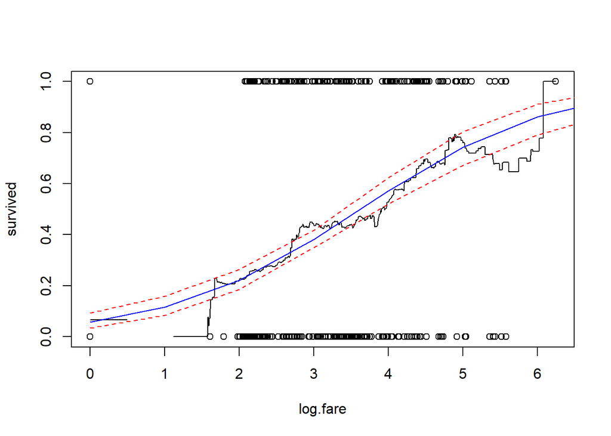

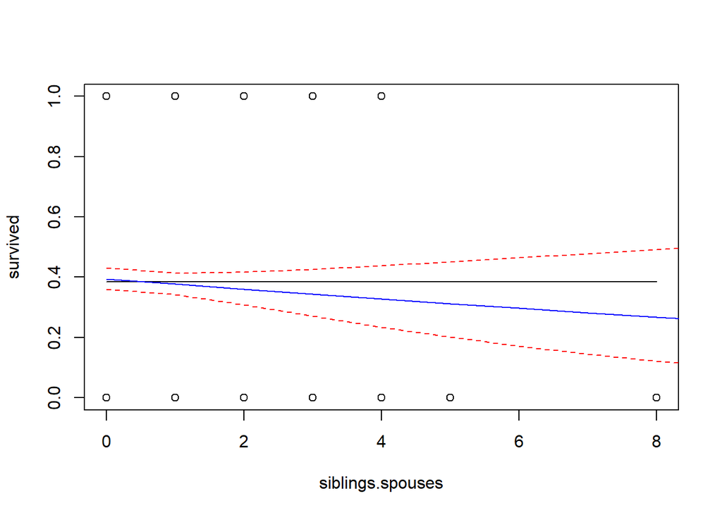

```
#>
#> Call:  glm(formula = formula, family = "binomial", data = dataset)
#>
#> Coefficients:
#>      (Intercept)  siblings.spouses
#>         -0.42898          -0.07201
#>
#> Degrees of Freedom: 886 Total (i.e. Null);  885 Residual
#> Null Deviance:       1183
#> Residual Deviance: 1182  AIC: 1186
```

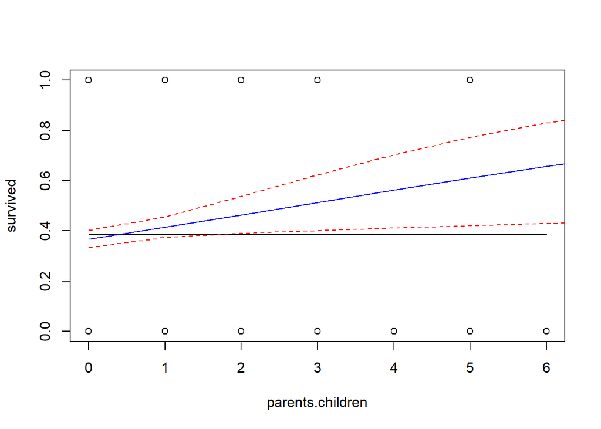

```
#>
#> Call:  glm(formula = formula, family = "binomial", data = dataset)
#>
#> Coefficients:
#>      (Intercept)  parents.children
#>          -0.5444            0.1991
#>
#> Degrees of Freedom: 886 Total (i.e. Null);  885 Residual
#> Null Deviance:       1183
#> Residual Deviance: 1177  AIC: 1181
```

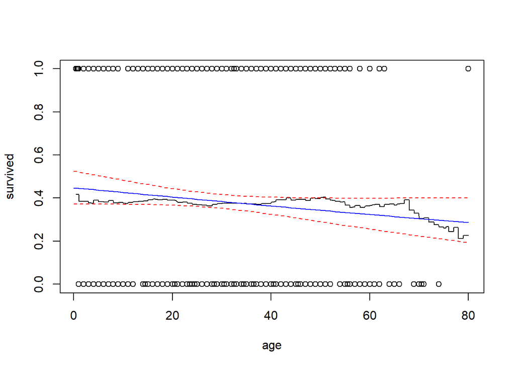

[output not shown]

## Survived vs age

Age vs survived

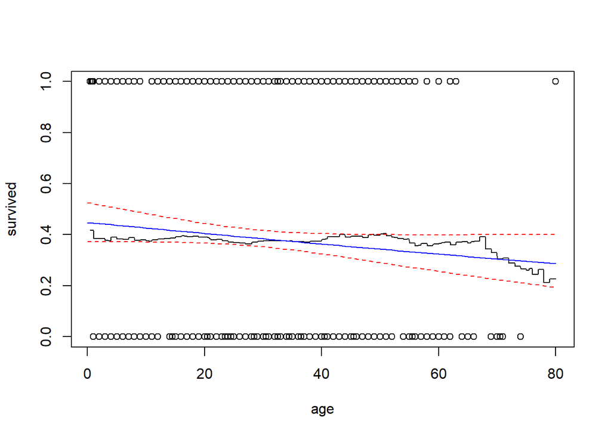

```
#>
#> Call:
#> glm(formula = formula, family = "binomial", data = dataset)
#>
#> Deviance Residuals:
#>     Min       1Q   Median       3Q      Max
#> -1.0864  -1.0017  -0.9439   1.3562   1.5806
#>
#> Coefficients:
#>              Estimate Std. Error z value Pr(>|z|)
#> (Intercept) -0.209189   0.159494  -1.312   0.1897
#> age         -0.008774   0.004947  -1.774   0.0761 .
#> ---
#> Signif. codes:  0 '***' 0.001 '**' 0.01 '*' 0.05 '.' 0.1 ' ' 1
#>
#> (Dispersion parameter for binomial family taken to be 1)
#>
#>     Null deviance: 1182.8  on 886  degrees of freedom
#> Residual deviance: 1179.6  on 885  degrees of freedom
#> AIC: 1183.6
#>
#> Number of Fisher Scoring iterations: 4
#>        r2CU
#> 0.004855108
```

Divide into age groups? - Children saved first - Mothers in certain age - Seniors not prioritized

```
#>                 0         1 count
#> (0,10]  0.4383562 0.5616438    73
#> (10,20] 0.6510067 0.3489933   149
#> (20,30] 0.6567657 0.3432343   303
#> (30,40] 0.5652174 0.4347826   184
#> (40,50] 0.5943396 0.4056604   106
#> (50,60] 0.6304348 0.3695652    46
#> (60,70] 0.8095238 0.1904762    21
#> (70,80] 0.8000000 0.2000000     5
```

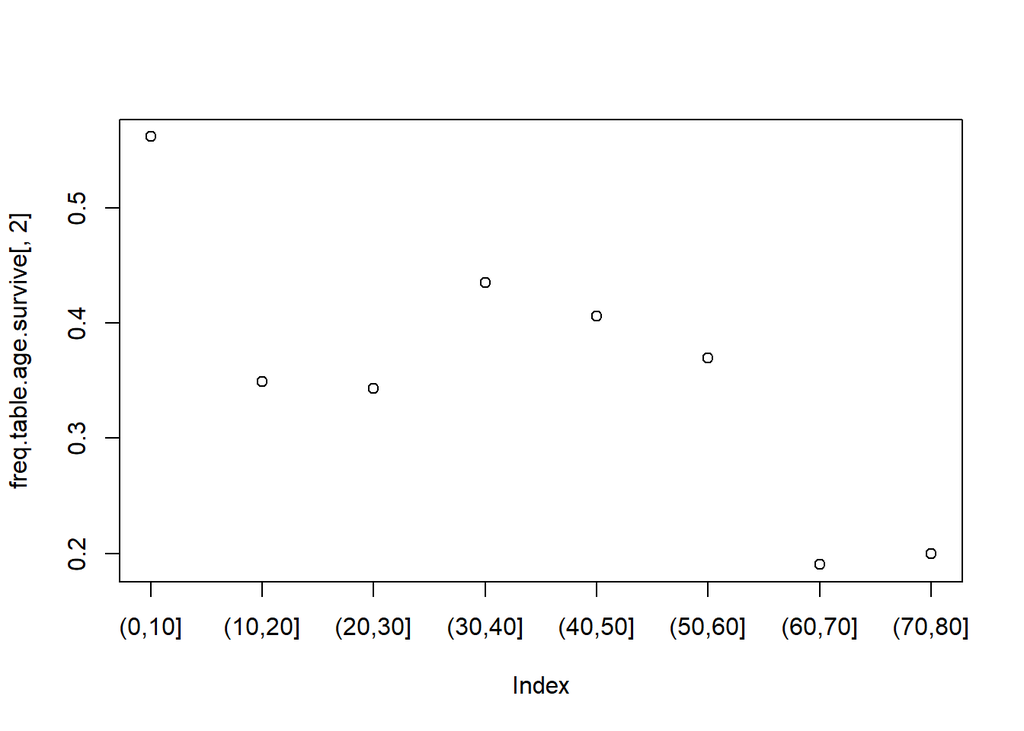

Good survival rate small children, then lower for young adults, higher for adults, low for seniors Little data on 50+, merge into one

```
#>                     0         1 count
#> Adult       0.5791139 0.4208861   316
#> Child       0.4468085 0.5531915    94
#> Young adult 0.6635731 0.3364269   431
#> Senior      0.7391304 0.2608696    46
```

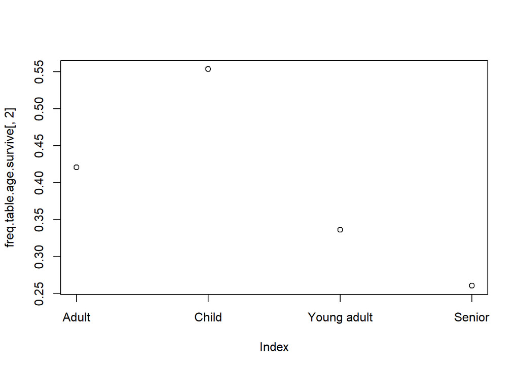

Quite spread out

```
#>
#>                 0   1   2   3   4   5   6
#>   Adult       253  39  14   2   2   5   1
#>   Child        11  46  37   0   0   0   0
#>   Young adult 372  27  28   3   1   0   0
#>   Senior       38   6   1   0   1   0   0
#>
#>                 0   1   2   3   4   5   8
#>   Adult       215  94   6   1   0   0   0
#>   Child        23  31   6  11  16   4   3
#>   Young adult 326  78  16   4   2   1   4
#>   Senior       40   6   0   0   0   0   0
```

Hard to distinquish children from parents and siblings from spouses

Next, fit model

```
#>
#> Call:
#> glm(formula = survived ~ age.group, family = "binomial", data = titanic)
#>
#> Deviance Residuals:
#>     Min       1Q   Median       3Q      Max
#> -1.2693  -1.0452  -0.9057   1.3156   1.6394
#>
#> Coefficients:
#>                      Estimate Std. Error z value Pr(>|z|)
#> (Intercept)           -0.3191     0.1139  -2.801   0.0051 **
#> age.groupChild         0.5327     0.2367   2.251   0.0244 *
#> age.groupYoung adult  -0.3601     0.1529  -2.355   0.0185 *
#> age.groupSenior       -0.7223     0.3546  -2.037   0.0416 *
#> ---
#> Signif. codes:  0 '***' 0.001 '**' 0.01 '*' 0.05 '.' 0.1 ' ' 1
#>
#> (Dispersion parameter for binomial family taken to be 1)
#>
#>     Null deviance: 1182.8  on 886  degrees of freedom
#> Residual deviance: 1162.7  on 883  degrees of freedom
#> AIC: 1170.7
#>
#> Number of Fisher Scoring iterations: 4
```

Significant

Look at beta, OR and prob with confidence interval

```
#>                            beta      2.5 %      97.5 %
#> (Intercept)          -0.3191370 -0.5440176 -0.09689437
#> age.groupChild        0.5327111  0.0703915  1.00017562
#> age.groupYoung adult -0.3601210 -0.6601917 -0.06052363
#> age.groupSenior      -0.7223169 -1.4543618 -0.05281085
#>                           beta     2.5 %    97.5 %
#> (Intercept)          0.7267760 0.5804117 0.9076519
#> age.groupChild       1.7035446 1.0729281 2.7187593
#> age.groupYoung adult 0.6975919 0.5167523 0.9412715
#> age.groupSenior      0.4856258 0.2335494 0.9485594
```

|  | age.group | pred$fit * 100 | 2.5 % | 97.5 % |
| --- | --- | --- | --- | --- |
| 1 | Adult | 42.08861 | 36.64513 | 47.53209 |
| 2 | Child | 55.31915 | 45.26858 | 65.36972 |
| 3 | Young adult | 33.64269 | 29.18195 | 38.10343 |
| 4 | Senior | 26.08696 | 13.39732 | 38.77659 |

Compare models, with fare

| model.name | aic | bic | sensitivity | specificity | PseudoR2 |
| --- | --- | --- | --- | --- | --- |
| age | 1183.593 | 1193.169 | 0.0000000 | 1.0000000 | 0.004855108 |
| group | 1170.680 | 1189.831 | 0.1520468 | 0.9229358 | 0.030409859 |
| even | 1179.740 | 1218.043 | 0.1198830 | 0.9412844 | 0.028822535 |
| !log.fare | 1118.570 | 1128.146 | 0.2397661 | 0.9302752 | 0.100493086 |
| fare | 1086.500 | 1096.075 | 0.3508772 | 0.8642202 | 0.145143916 |
| fare + age | 1077.340 | 1091.703 | 0.3888889 | 0.8366972 | 0.160306854 |
| fare + group | 1079.418 | 1103.358 | 0.3947368 | 0.8311927 | 0.162898086 |
| fare + even | 1085.208 | 1128.298 | 0.4093567 | 0.8348624 | 0.165872942 |
| fare * group | 1062.521 | 1100.823 | 0.4356725 | 0.8348624 | 0.193352052 |

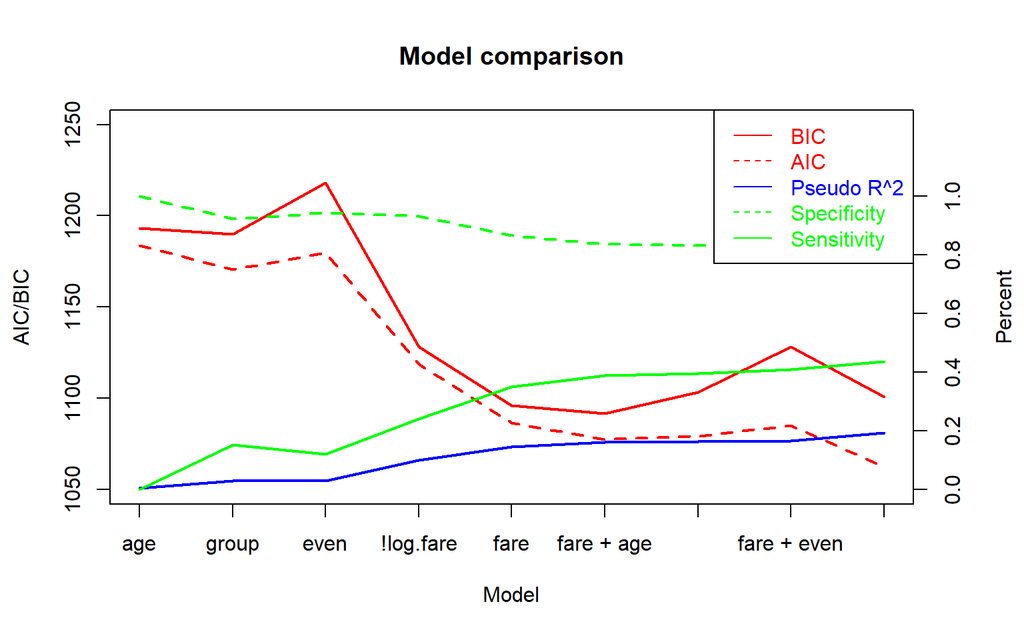

Remove the worst

| model.name | aic | bic | sensitivity | specificity | PseudoR2 |
| --- | --- | --- | --- | --- | --- |
| fare | 1086.500 | 1096.075 | 0.3508772 | 0.8642202 | 0.1451439 |
| fare + age | 1077.340 | 1091.703 | 0.3888889 | 0.8366972 | 0.1603069 |
| fare + group | 1079.418 | 1103.358 | 0.3947368 | 0.8311927 | 0.1628981 |
| fare * group | 1062.521 | 1100.823 | 0.4356725 | 0.8348624 | 0.1933521 |

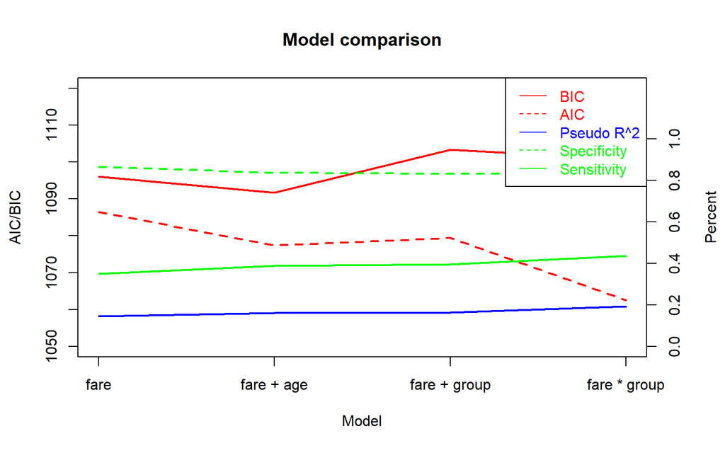

## Sex

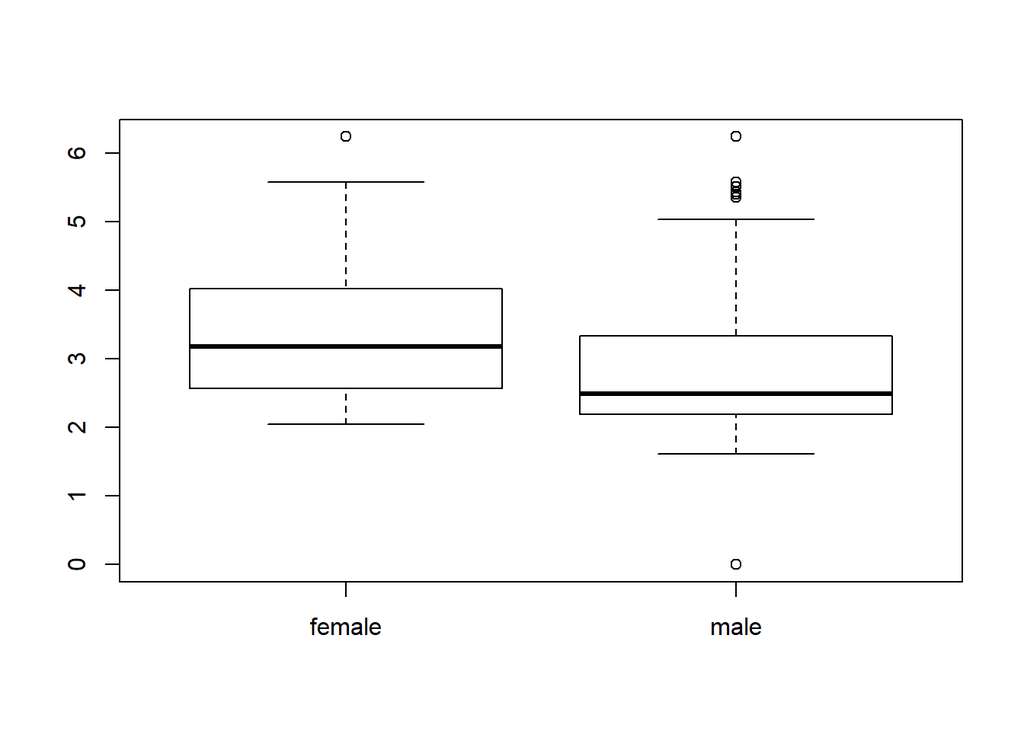

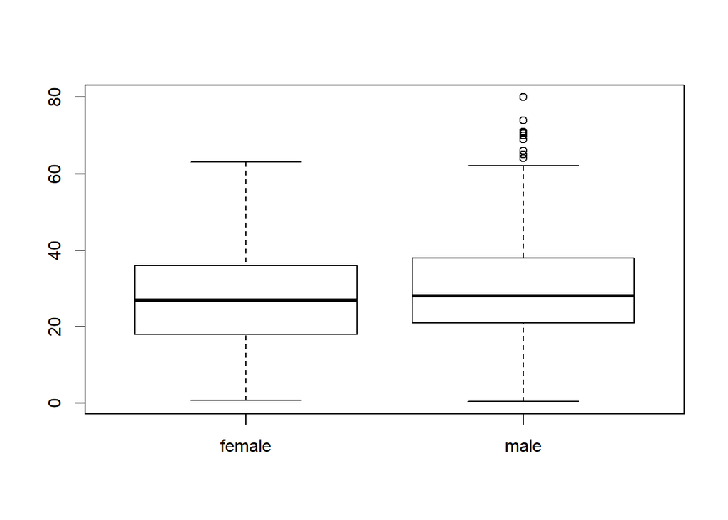

```
#>
#>            0   1
#>   female  81 233
#>   male   464 109
#>
#>                  0         1
#>   female 0.2579618 0.7420382
#>   male   0.8097731 0.1902269
```

```
#>
#> Call:
#> glm(formula = survived ~ sex, family = "binomial", data = titanic)
#>
#> Deviance Residuals:
#>     Min       1Q   Median       3Q      Max
#> -1.6462  -0.6496  -0.6496   0.7725   1.8218
#>
#> Coefficients:
#>             Estimate Std. Error z value Pr(>|z|)
#> (Intercept)  -1.4485     0.1064  -13.61   <2e-16 ***
#> sexfemale     2.5051     0.1672   14.98   <2e-16 ***
#> ---
#> Signif. codes:  0 '***' 0.001 '**' 0.01 '*' 0.05 '.' 0.1 ' ' 1
#>
#> (Dispersion parameter for binomial family taken to be 1)
#>
#>     Null deviance: 1182.77  on 886  degrees of freedom
#> Residual deviance:  916.12  on 885  degrees of freedom
#> AIC: 920.12
#>
#> Number of Fisher Scoring iterations: 4
```

```
#>                  beta     2.5 %    97.5 %
#> (Intercept) -1.448537 -1.661874 -1.244209
#> sexfemale    2.505126  2.182031  2.838020
#>                   beta    2.5 %     97.5 %
#> (Intercept)  0.2349138 0.189783  0.2881687
#> sexfemale   12.2451014 8.864293 17.0819087
```

|  | sex | pred$fit * 100 | 2.5 % | 97.5 % |
| --- | --- | --- | --- | --- |
| 1 | female | 74.20382 | 69.36453 | 79.04311 |
| 2 | male | 19.02269 | 15.80905 | 22.23632 |

# Is alone

```
#>
#>   0   1
#> 354 533
#>         survived
#> is.alone   0   1
#>        0 175 179
#>        1 370 163
#> png
#>   2
#>            survived
#> is.alone    Not survived  Survived
#>   Not alone    0.4943503 0.5056497
#>   Alone        0.6941839 0.3058161
#>            survived
#> is.alone    Not survived  Survived
#>   Not alone    0.3211009 0.5233918
#>   Alone        0.6788991 0.4766082
```

Most were alone

Of those who were alone, less survived

Of those who survived, about 50% were alone, of those who did not survive, most were alone